[figure not shown]

CLASE 1

INTRODUCCIÓN AL CURSO ANÁLISIS

AVANZADO DE DATOS II

Gabriel Sotomayor

Marzo 2024

PRESENTACIÓN

El curso profundiza las principales técnicas multivariantes, que permiten analizar en

forma conjunta la interacción de múltiples factores, lo cual da la posibilidad de

estudiar de forma más compleja los problemas sociales.

Se enfatizan la comprensión de procedimientos e interpretación de resultados, así

como el uso de herramientas computacionales, principalmente en R y RStudio. Se

trabajará en la aplicación de los métodos sin necesidad de estudiar en profundidad

los fundamentos matemáticos de todos ellos.

Al final del curso el alumno deberá ser capaz de realizar análisis descriptivo de los

datos tanto primarios como secundarios y poder seleccionar la técnica estadística

adecuada a utilizar cuando se tienen datos multivariables.

RESULTADOS DE APRENDIZAJE

Resultado general: Entregar herramientas al alumno para que pueda abordar el

análisis de datos desde la estadística multivariante descriptiva e inferencial,

elaborando y probando hipótesis y desarrollando modelos explicativos de

determinados fenómenos de estudio.

RESULTADOS ESPECÍFICOS

1. Manejar bases de datos complejas.

2. Plantear y estructurar adecuadamente un problema de análisis multivariante.

3. Identificar el tipo de técnica adecuada, o combinación de ellas, a aplicar en cada

situación concreta.

4. Comprender las herramientas utilizada en cada una de las técnicas estudiadas.

5. Aprender a utilizar los programas computacionales necesarios para aplicar los distintos

modelos estudiados, particularmente R.

6. Interpretar los resultados del análisis.

7. Redactar correctamente un informe con los resultados del análisis.

[figure not shown]

CONTENIDOS

1. Gestión de datos con R

• Introducción a R y

Rstudio

• Gestión de datos con

tidyverse.

• Cálculo de estadísticos descriptivos.

• Visualización de datos con

ggplot.

2. Introducción a los modelos

multivariados

• Uso de modelos en ciencias sociales

• Modelos exploratorios y modelos confirmatorios

• Repaso de conceptos estadísticos: covarianza, correlación e inferencia.

• Supuestos de análisis.

3. Formas funcionales de los

Modelos de Regresión

• Introducción

• Modelo Logarítmico bivariado

• Modelo Logarítmico Multivariado

• Interpretación de los coeficientes

• Ejemplos de aplicación en R.

[figure not shown]

CONTENIDOS

4

. Análisis

Factorial

Exploratorio

• Análisis factorial exploratorio y su aplicación en la investigación sociológica. El

concepto de varianza y covarianza.

• Diferencias entre el análisis de componente principal y de factor común.

Supuestos de la técnica.

• La extracción de factores comunes. Métodos de extracción de factores, criterios

de selección del número de factores y rotación.

• La matriz factorial y su interpretación. Evaluación del modelo factorial y cálculo

de puntuaciones factoriales.

5. Análisis Factorial

Confirmatorio

• Análisis factorial confirmatorio y su aplicación en la investigación sociológica. El

análisis confirmatorio frente al análisis exploratorio. Supuestos de la técnica.

• Especificación e identificación del modelo. Estimación de parámetros, evaluación

del ajuste y

reespecificación.

• Fiabilidad y validez de los modelos de medida. Validez convergente y validez

discriminante. Evaluación de la capacidad confirmatoria del modelo.

• Ejemplo de análisis factorial confirmatorio.

[figure not shown]

CONTENIDOS

6

. Análisis de Sendero

• Análisis de sendero y su aplicación en la investigación sociológica. Supuestos de

la técnica.

• Especificación del modelo.

• Evaluación del modelo de medición y de la capacidad confirmatoria del

modelo. • Ejemplo de análisis de sendero.

7. Modelos de Ecuaciones

estructurales

• Análisis de ecuaciones estructurales y su aplicación en la investigación

sociológica.

• La obtención de un modelo de ecuaciones estructurales: la estructura del modelo.

Supuestos de la técnica.

• Estimación del modelo empírico.

• Evaluación del modelo.

• Introducción de modificaciones y/o conclusión del análisis. Evaluación de la

capacidad confirmatoria del modelo.

• Ejemplos sobre modelamiento de ecuaciones estructurales.

[figure not shown]

BIBLIOGRAFÍA

1

ANALISIS

ESTADISTICO MULTIVARIANTE -

UN ENFOQUE TEORICO Y PRACTICO

DE LA GARZA

GARCIA,

JORGE

2013

2

Análisis de datos multivariantes.

Peña, Daniel

2002

3

Análisis Multivariado Aplicado

URIEL Y ALDAS

2005, 1ª.

Edición

4

Análisis Multivariante para las Ciencias Sociales

LEVI J.P. y

VARELA J.;

2001

5

Modelos de Ecuaciones Estructurales Cuadernos de estadística

Batista,J.M

. y Coenders G.,

2012

,

6

Introducción al Análisis de Regresión Lineal

Montgomery, Peck y

Vining 2006,

7

El análisis factorial como técnica de investigación en Psicología

Ferrando, P. J., & Anguiano

-Carrasco, C. 2010

8

Análisis factorial confirmatorio. Su utilidad en la validación de cuestionarios

relacionados con la salud.

. Batista

-Foguet, J.M., Coenders, G., &

Alonso, J.

2004

9

El

Path Analysis: conceptos básicos y ejemplos de aplicación.

Pérez, E., Medrano, L. A.,& Rosas, J. S

2013

10

Modelos de ecuaciones estructurales

Ruiz, M.A., Pardo, A., & San Martín, R.

2010

11

RStudio para Estadística Descriptiva en Ciencias Sociales. Manual de apoyo docente

para la asignatura Estadística Descriptiva

Boccardo, G. y Ruiz, F.

2019

12

R para Ciencia de Datos

https://es.r4ds.hadley.nz/index.html

Wickham, H

2019

[figure not shown]

EVALUACIONES

Evaluación

Fechas

Porcentaje

Evaluación de R

25

de marzo

15 de abril

27 de mayo

17 de junio

30%

Prueba 1

29

de abril

35%

Trabajo de investigación

1 de julio

35%

[figure not shown]

AYUDANTÍAS

El curso tiene dos ayudantes:

Patrio Alarcón patricio.alarcon@mail.udp.cl

Fernanda Hurtado fernanda.hurtado@mail.udp.cl

Están disponibles para responder las dudas que puedan tener a lo largo del curso,

tanto estadísticas como de uso de software.

Habrá sesiones de ayudantía cada 2 semanas aproximadamente, centradas en la

aplicación de las técnicas que revisaremos en R.

También les acompañarán en la realización de tareas y trabajos de investigación.

[figure not shown]

PÁGINA DEL CURSO

https://aadii2024.netlify.app/

DELEGADO DE CURSO

Las comunicaciones del curso con el equipo docente para temas colectivos deberán

gestionarse de manera centralizada mediante un delegado, especialmente

considerando que hay alumnos de distintas generaciones.

Esto es particularmente relevante para solicitudes respecto a evaluaciones.

OBJETIVOS DE LA SESIÓN

Reflexionar sobre el uso de software estadístico en ciencias sociales.

Introducir el uso de R y Rstudio para ciencias sociales.

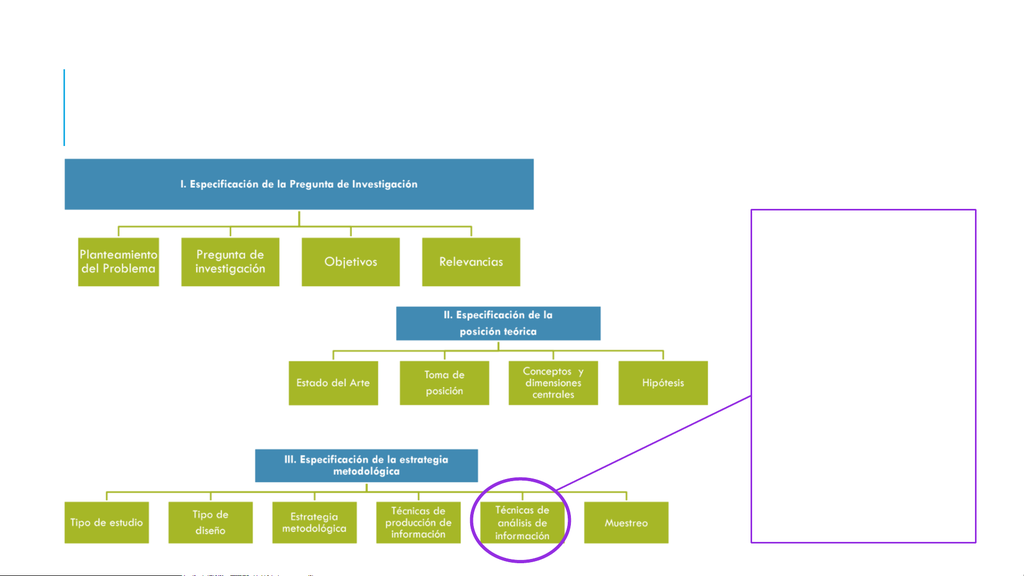

¿DONDE SE SITÚA LA ESTADÍSTICA Y EL USO DE

SOFTWARE EN EL PROCESO DE INVESTIGACIÓN?

El uso de software y

estadística es una pequeña

parte del proceso de

diseño de una

investigación, por lo que es

importante no confundir

ambos procesos ni

anteponer el uso de

determinadas herramientas

al proceso general de

investigación, debe primar

el problema a investigar

USO DE SOFTWARE EN CIENCIAS SOCIALES

Progresivamente se ha generalizado el uso de software estadístico en ciencias

sociales, abriendo grandes posibilidades de realizar análisis más complejos y

facilitando su uso.

Riesgo de falta de formación estadística y reflexividad (calidad del análisis)

Dos niveles de manejo del software:

1. Ejecución básica y correcta interpretación de las salidas estadísticas (necesario

mínimo para utilizar la herramienta e interpretar otras investigaciones).

2. Manejo avanzado de software y procedimientos estadísticos. Nivel deseable

para un uso reflexivo de las herramientas y lectura crítica de otras

investigaciones.

[figure not shown]

¿QUÉ SOFTWARE EXISTEN Y CUÁL UTILIZAR?

[figure not shown]

¿QUÉ SOFTWARE EXISTEN Y CUÁL UTILIZAR?

Dimensión / Lenguaje R Python SPSS Excel Stata

Alcance General, orientación

multidisciplinar

General, orientación

multidisciplinar

Limitado, orientado a

Ciencias Sociales

Limitado, orientado a

administración

Limitado, orientado a

Economía

Licencia Libre (freeware) Libre (freeware) Pagada (versión de

prueba limitada)

Pagada (versión de

prueba limitada)

Pagada (versión de

prueba limitada)

Aprendizaje Sintaxis, poco intuititvo Sintaxis, poco intuititvo Botones y sintaxis,

intuitivo

Botones y sintaxis,

intuitivo

Botones y sintaxis,

intuitivo

Visualización Avanzada Intermedia Básica Intermedia Intermedia

Análisis de texto Intermedio, poca

eficiencia

Avanzado, amplia

eficiencia No No No

Minería Datos Intermedio, poca

eficiencia

Avanzado, amplia

eficiencia No No No

Sistema operativo Windows, Mac OS, Linux Windows, Mac OS, Linux Windows, Mac OS Windows, Mac OS Windows, Mac OS

(Boccardo y Ruiz, 2018)

[figure not shown]

¿QUÉ ES R?

R es un software y un lenguaje de programación, ambos

de carácter libre, enfocado principalmente en el análisis y

visualización de datos. Es desarrollado por The R

Foundation for Statistical Computing.

Funciona con una lógica de objetos, sobre los que

podemos trabajar con operadores y funciones.

El hecho de que sea un lenguaje de programación nos

permite programar funciones, por lo que es posible

pasar de ser usuarios a programadores.

Instalamos una versión básica y podemos agregar

paquetes con nuevas funciones.

Su interfaz es poco amigable, la solución: R Studio.

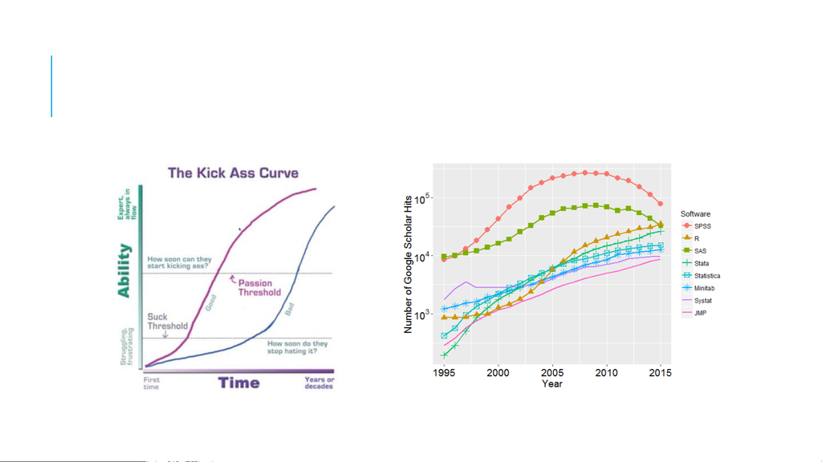

¿PORQUÉ APRENDER Y USAR R Y RSTUDIO?

¿PORQUÉ USAR R?

1. Es libre y gratis.

2. Por lo anterior ofrece grandes

posibilidades de personalización de los

análisis y amplitud de herramientas (en

actualización).

3. Amplia y creciente comunidad de usuarios

desarrollando funciones y resolviendo

problemas en internet (la mayoría en inglés).

1. Replicabilidad: Permite a otros entender

como construimos nuestros resultados y

replicarlos, cada vez más importante en la

ciencia.

2. Eficiencia: En condiciones “reales” de trabajo

resulta más eficiente que trabajar con botones

(aunque ahora pueda parecer contraintuitivo)

3. Control: Permite tener claridad de todas las

etapas de nuestros análisis, cuestión que en otros

software son realizadas por defecto.

(Elousa, 2009 en Boccardo y Ruiz, 2018: 8-9)

¿PORQUÉ TRABAJAR CON SINTAXIS?

[figure not shown]

R STUDIO

Es una interfaz gráfica para R que nos permite

tener mejor visualización y control de los

procesos que realizamos.

Tiene 4 partes principales:

1. Editor de Sintaxis: formato de block de notas

donde podemos construir nuestra sintaxis.

2. Ambiente de trabajo (Environment): muestra los

objetos que hemos creado (memoria temporal –

RAM)

3. Consola de R: Aquí es donde podemos ver los

resultados de nuestros análisis, las operaciones

ejecutadas y mensajes de error.

4. Panel de visualización: Aquí aparecen los gráficos

que ejecutemos, además de tener la pestaña help

y nuestro directorio de trabajo.

1

2

3

4

[figure not shown]

INSTALAR R Y RSTUDIO

Instalar R

Podemos encontrar R para Windows, Linux y Mac en

https://cloud.r-project.org/

Debemos descargar el paquete base, luego ejecutar el

instalador, e instalarlo según las opciones predeterminadas

Podemos encontrar R Studio en su sitio web, y bajar la versión

gratis, que contiene todas las funciones

https://www.rstudio.com/products/rstudio/download/

Debemos fijarnos en elegir el sistema operativo correcto.

Igualmente lo ejecutamos e instalamos según las opciones

predeterminadas

[figure not shown]

EL PROBLEMA DE JAVA X64

Para algunos análisis R se basa en Java,

el problema es que nuestros

computadores suelen instalar de manera

automática la versión de 32 bits, porque

los navegadores de internet funcionan (o

funcionaban) en esta arquitectura, pero

nuestro computadores y R funcionan a

64 bits.

Para resolverlo debemos descargar e

instalar la versión offline de 64 bits de

Java

https://www.java.com/es/download/ma

nual.jsp

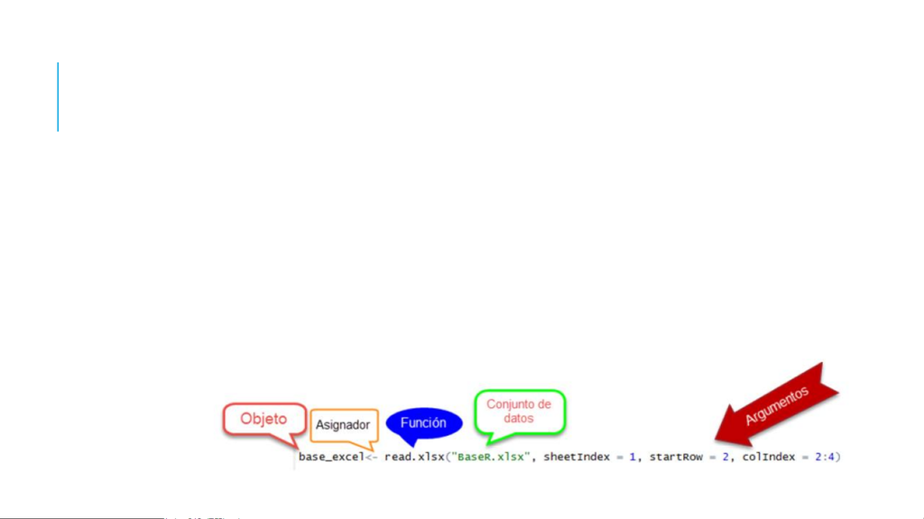

PROGRAMACIÓN POR OBJETOS Y FUNCIONES

Tipos de estructuras de datos en R

Vector (vector): columna o fila de datos de un mismo tipo

(una variable individual)

Listas (list): Nos permiten agrupar objetos de distinto tipo.

Matrices (matrix): arreglo de dos dimensiones de datos

de un mismo tipo (conjunto de variables)

Data.frame (base de datos): Matriz de datos en el que

las columnas tienen asignado nombres, y que permite usar

todo tipo de datos.

Tipos de variables en R

Numérico (numeric; números con decimales)

Números enteros (integer)

Lógicos: Verdadero o Falso

Variables cadena o texto (string / character)

Factores (factor): para variables cualitativas (nominales)

Estructura básica de

la sintaxis de R

[figure not shown]

¿COMO CONTINUAR?

Dominar R es un camino de mediano plazo y es importante desarrollar habilidad de “hacking”, es decir:

1. estar dispuesto a buscar respuestas de manera autónoma

2. saber donde buscar la información

3. utilizar nuevos datos y paquetes por su cuenta

Donde buscar:

GOOGLE! (preferentemente en inglés) y youtube

Pedir ayuda a otros usuarios

Pestaña “help”

https://www.rdocumentation.org/

https://stackoverflow.com/

Chat GPT*

Además hay múltiples recursos web para aprender R de manera profunda y guiada.

Cuestiones importantes que no revisamos: visualización de datos con ggplot2, el tidyverse (paquete dplyr),

y profundizar en programación en R (loops y funciones), programación literada (Rmarkdown).

[figure not shown]

BIBLIOGRAFÍA Y

OTROS RECURSOS

PARA PROFUNDIZAR

Boccardo, Giorgio y Ruiz, Felipe. Uso de RStudio para Estadística

Univariada en Ciencias Sociales. Manual de apoyo docente para la

asignatura Estadística Descriptiva. Santiago: Departamento de

Sociología, Facultad de Ciencias Sociales, Universidad de Chile.

Disponible aquí.

Grolemund, Garrett y Wickham Hadley. R para Ciencia de Datos.

https://es.r4ds.hadley.nz/

Paradis, E. (2003). R para Principiantes. Francia: Institut des

Sciences de l’Évolution. Disponible en: https://cran.r-

project.org/doc/contrib/rdebuts_es.pdf

Sitios web útiles

http://www.sthda.com

Cursos online (inglés)

Especialización en Ciencia de Datos Universidad John Hopkins

https://www.coursera.org/specializations/jhu-data-science

Data Camp https://www.datacamp.com/courses/tech:r